# Milestone Report - Data Science Capstone

### (4) Data Cleaning

```r
pathname  <- "c:/Users/Ali/Desktop/R/Data/en_US"
for (fs in c("blogs", "twitter", "news")){
        #
        fullpath_in  <- sprintf("%s%s%s%s", pathname,"/en_US.", fs,".txt")
        fullpath_out <- sprintf("%s%s%s%s", pathname,"/sample/", fs,".txt")
        #
        con <- file(fullpath_in, "r")
        lines_in    <- readLines(con, skipNul = TRUE)
        sampleout   <- ceiling(runif(n=0.2*length(lines_in), min=0, max=length(lines_in)))
        line_out    <- lines_in[sampleout]
        write.table(line_out, file=fullpath_out, row.names=FALSE, col.names=FALSE)
        close(con)
}
```

```r
library(tm)
importsamples <- function(filename){
        #
        fullpath_in  <- sprintf("%s%s%s%s", pathname,"/sample/", filename,".txt")
        con <- file(fullpath_in, "r")
        lines_in    <- readLines(con, skipNul = TRUE)
        close(con)
        return(list(lines_in, filename))
}
CleanCorpus <- function(corpus){
        corpus.tmp <-  tm_map(corpus, removePunctuation)
        corpus.tmp <-  tm_map(corpus.tmp, stripWhitespace)
        corpus.tmp <-  tm_map(corpus.tmp, tolower)
        corpus.tmp <-  tm_map(corpus.tmp, removeNumbers)
        corpus.tmp <-  tm_map(corpus.tmp, removeWords, stopwords("english"))
        return(corpus.tmp)
}
# Build the Corpus
sampledata <- lapply(file_source, importsamples)
thecorpus  <- Corpus(VectorSource(sampledata))

# Clean and TDM the Corpus
thecorpus.clean <- CleanCorpus(thecorpus)
thecorpus.TDM   <- TermDocumentMatrix(thecorpus.clean)
str(thecorpus.TDM)
```

```
## List of 6
##  $ i       : int [1:363421] 1 2 3 4 5 6 7 8 9 10 ...
##  $ j       : int [1:363421] 1 1 1 1 1 1 1 1 1 1 ...
##  $ v       : num [1:363421] 8 1 1 1 1 1 1 1 1 2 ...
##  $ nrow    : int 277386
##  $ ncol    : int 3
##  $ dimnames:List of 2
##   ..$ Terms: chr [1:277386] "aaa" "aaaaaaaaaaaaaa" "aaaaaaaaaaaaaaaaa" "aaaaaaaaaaaargh" ...
##   ..$ Docs : chr [1:3] "1" "2" "3"
##  - attr(*, "class")= chr [1:2] "TermDocumentMatrix" "simple_triplet_matrix"
##  - attr(*, "weighting")= chr [1:2] "term frequency" "tf"
```

### (5) Word Frequency

Perhaps the first step to explore the content of these files is sorting the most frequent words.The plot blow illustrates the numbre of times the top 20 words have been useds in a small (but random) dataset extracted from the original data.

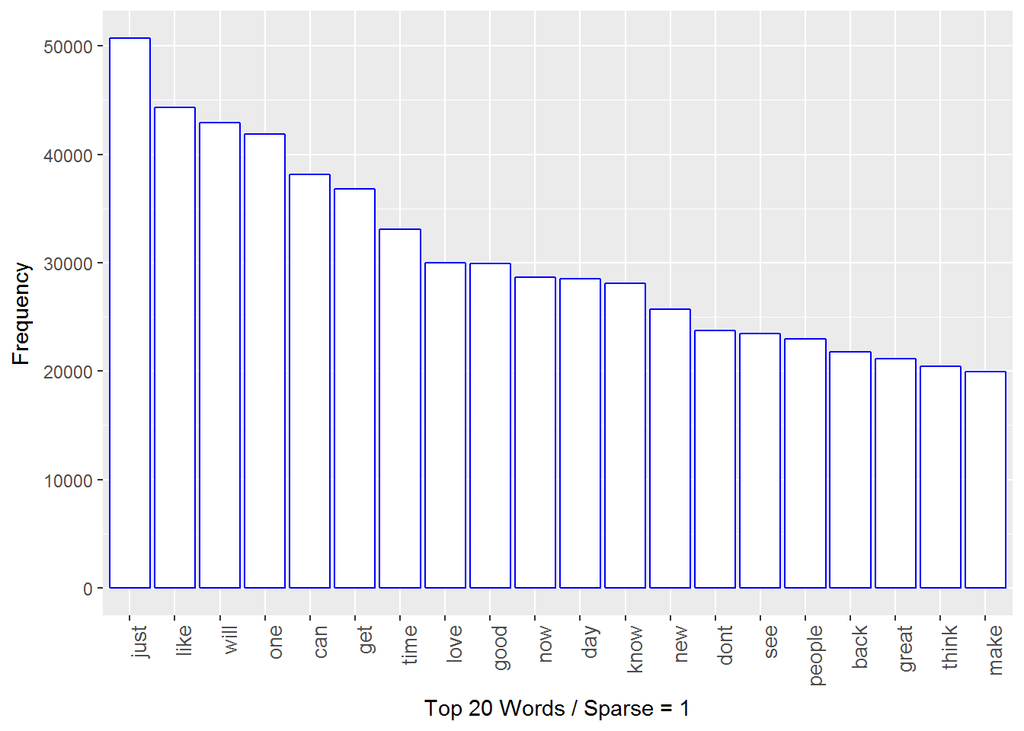

```r
library(tm); library(ggplot2)
options(mc.cores=1)
#
freq    <- sort(rowSums(as.matrix(thecorpus.TDM)), decreasing = TRUE)
freq.df <- data.frame(word = names(freq), freq = freq)
ggplot  (freq.df[1:20,], aes(reorder(word, -freq), freq)) +
        labs(x = "Top 20 Words / Sparse = 1", y = "Frequency") +
        theme(axis.text.x = element_text(angle = 90, size = 10, hjust = 1))+
        geom_bar(stat = "identity", fill = "white", colour = "blue")
```

### (5) Conclustion

This was a quick exploration. In the next steps of this capstone, we will review more details of the data.This data and a model can then help building a product (Shiny Web App) to predict the words a user wants to type in before s/he complete typing.